# Practical Machine Learning Course Project: Human Activity Recognition

Sergii Sorokolat

7/11/2018

## Executive summary

Human Activity Recognition - HAR - has emerged as a key research area in the last years and is gaining increasing attention by the pervasive computing research community, especially for the development of context-aware systems.

Using devices such as Jawbone Up, Nike FuelBand, and Fitbit it is now possible to collect a large amount of data about personal activity relatively inexpensively. One thing that people regularly do is quantify how much of a particular activity they do, but they rarely quantify how well they do it. In this project, the goal will be to use data from accelerometers on the belt, forearm, arm, and dumbell of 6 participants. They were asked to perform barbell lifts correctly and incorrectly in 5 different ways.

The goal of the project is to predict the manner in which they did the exercise (**classe** variable in the training set). This analysis will show that the prediction model based on Random Forests has the best accuracy.

The source code for this analysis is available here: https://github.com/datasalad/pml

## Dataset

The training data for this project are available here: https://d396qusza40orc.cloudfront.net/predmachlearn/pml-training.csv

The test data are available here: https://d396qusza40orc.cloudfront.net/predmachlearn/pml-testing.csv

Six young health participants were asked to perform one set of 10 repetitions of the Unilateral Dumbbell Biceps Curl in five different fashions: exactly according to the specification (Class A), throwing the elbows to the front (Class B), lifting the dumbbell only halfway (Class C), lowering the dumbbell only halfway (Class D) and throwing the hips to the front (Class E).

Class A corresponds to the specified execution of the exercise, while the other 4 classes correspond to common mistakes. Participants were supervised by an experienced weight lifter to make sure the execution complied to the manner they were supposed to simulate. The exercises were performed by six male participants aged between 20-28 years, with little weight lifting experience. We made sure that all participants could easily simulate the mistakes in a safe and controlled manner by using a relatively light dumbbell (1.25kg).

Read more: http://groupware.les.inf.puc-rio.br/har#ixzz5KwJtoTWF

## Reading and processing the data

```r
library(tidyverse)
library(caret)

## read training data
csv <- read.csv("pml-training.csv", header = TRUE, na.strings = c("NA", "", "#DIV/0!"))

## remove clolumns with missing values
csv <- csv[, colSums(is.na(csv)) == 0]

## define a tibble with the data
t <- tbl_df(csv)
dim(t)
```

```
## [1] 19622    60
```

We also remove redundant columns:

```r
idx <- grepl("X|timestamp|new_window|user_name", names(t))
t <- t[, !idx]
```

```r
names(t)
```

```
##  [1] "num_window"           "roll_belt"            "pitch_belt"
##  [4] "yaw_belt"             "total_accel_belt"     "gyros_belt_x"
##  [7] "gyros_belt_y"         "gyros_belt_z"         "accel_belt_x"
## [10] "accel_belt_y"         "accel_belt_z"         "magnet_belt_x"
## [13] "magnet_belt_y"        "magnet_belt_z"        "roll_arm"
## [16] "pitch_arm"            "yaw_arm"              "total_accel_arm"
## [19] "gyros_arm_x"          "gyros_arm_y"          "gyros_arm_z"
## [22] "accel_arm_x"          "accel_arm_y"          "accel_arm_z"
## [25] "magnet_arm_x"         "magnet_arm_y"         "magnet_arm_z"
## [28] "roll_dumbbell"        "pitch_dumbbell"       "yaw_dumbbell"
## [31] "total_accel_dumbbell" "gyros_dumbbell_x"     "gyros_dumbbell_y"
## [34] "gyros_dumbbell_z"     "accel_dumbbell_x"     "accel_dumbbell_y"
## [37] "accel_dumbbell_z"     "magnet_dumbbell_x"    "magnet_dumbbell_y"
## [40] "magnet_dumbbell_z"    "roll_forearm"         "pitch_forearm"
## [43] "yaw_forearm"          "total_accel_forearm"  "gyros_forearm_x"
## [46] "gyros_forearm_y"      "gyros_forearm_z"      "accel_forearm_x"
## [49] "accel_forearm_y"      "accel_forearm_z"      "magnet_forearm_x"
## [52] "magnet_forearm_y"     "magnet_forearm_z"     "classe"
```

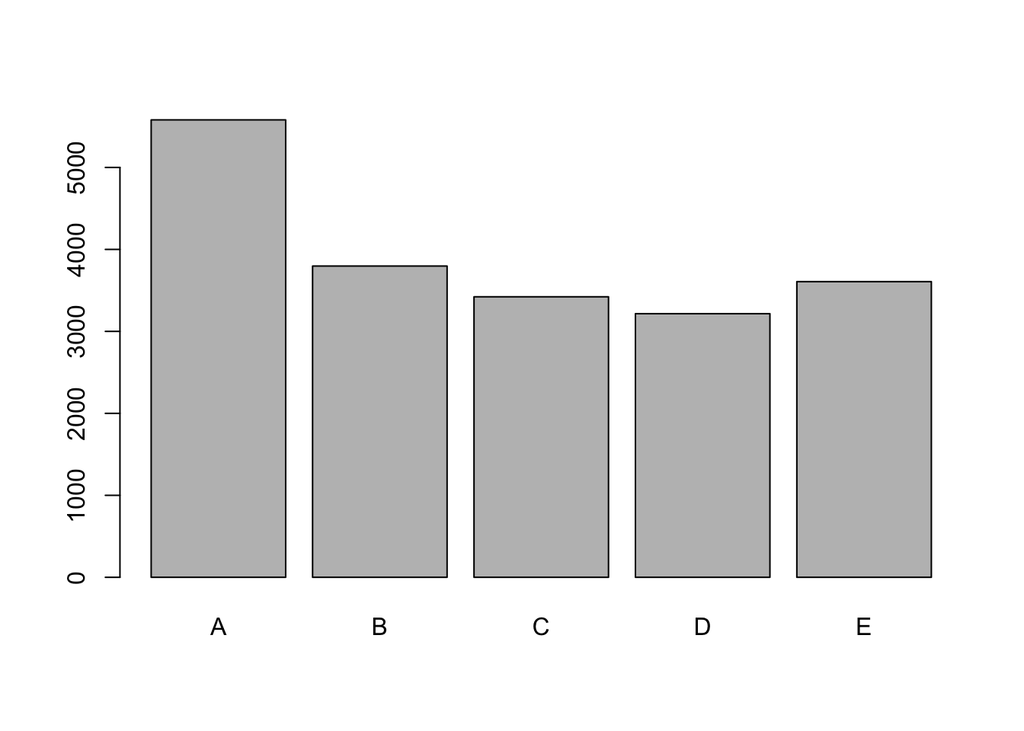

```r
barplot(table(t$classe))
```

## Modelling

```r
library(caret)
inTrain <- createDataPartition(y = t$classe, p = 0.7)[[1]]

training <- t[inTrain,]
testing <- t[-inTrain,]
```

## Correlation plot

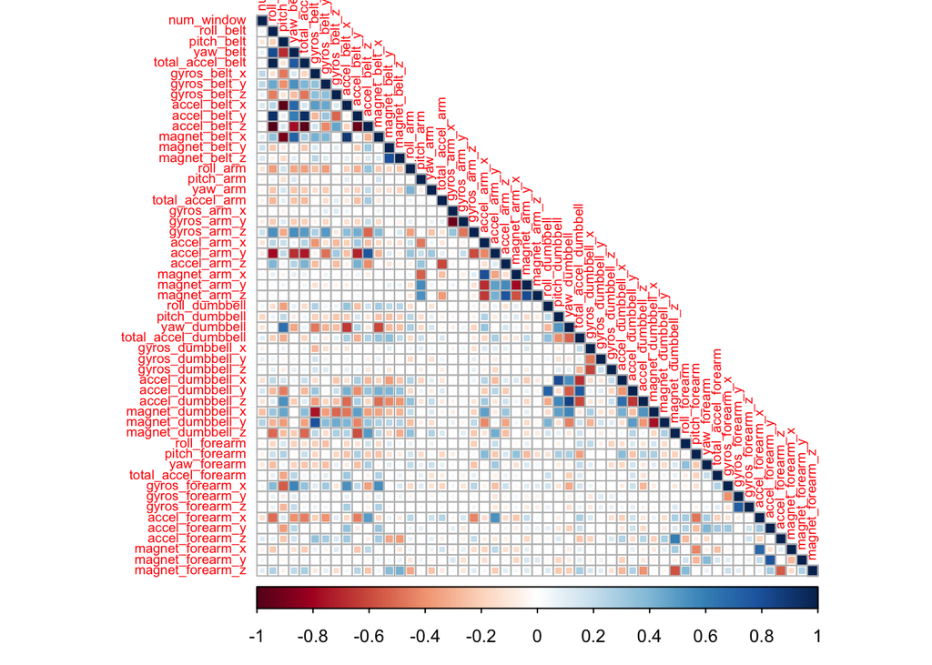

```r
library(corrplot)
cor <- cor(testing[,-54])
corrplot(cor, type = "lower", method = "square", cl.pos = "b", tl.cex=.6)
```

Remove predictors with extremely high correlation (>= 0.9)

```r
hc <- findCorrelation(cor, cutoff = 0.9, verbose = FALSE)
training <- training[,-hc]
```

## Cross validation

K-fold cross validation with k = 10 will be used.

```r
fitCtrl <- trainControl(method = "cv", number = 10)
```

### Classification And Regression Tree approach with PCA preprocessing

```r
set.seed(123321)
fitTree <- train(classe ~ ., data = training, method = "rpart", preProcess = "pca", trControl = fitCtrl)
fitTree
```

```
## CART
##
## 13737 samples
##    48 predictor
##     5 classes: 'A', 'B', 'C', 'D', 'E'
##
## Pre-processing: principal component signal extraction (48), centered
##  (48), scaled (48)
## Resampling: Cross-Validated (10 fold)
## Summary of sample sizes: 12365, 12363, 12363, 12363, 12363, 12362, ...
## Resampling results across tuning parameters:
##
##   cp          Accuracy   Kappa
##   0.03234666  0.3914283  0.2109863
##   0.03997559  0.3749729  0.1778150
##   0.06558336  0.3334784  0.1117763
##
## Accuracy was used to select the optimal model using the largest value.
## The final value used for the model was cp = 0.03234666.
```

### LDA approach

```r
set.seed(123321)
fitLda <- train(classe ~ ., data = training, method = "lda", trControl = fitCtrl)
fitLda
```

```
## Linear Discriminant Analysis
##
## 13737 samples
##    48 predictor
##     5 classes: 'A', 'B', 'C', 'D', 'E'
##
## No pre-processing
## Resampling: Cross-Validated (10 fold)
## Summary of sample sizes: 12365, 12363, 12363, 12363, 12363, 12362, ...
## Resampling results:
##
##   Accuracy   Kappa
##   0.6847172  0.6012076
```

### Random forest approach

Random forests should be very useful for this type of problem (classification). The main idea behind this algorithm is the following:

1. Bootstrap samples
2. At each split, bootstrap variables
3. Grow multiple trees and tune

Pros of this approach is accuracy. Cons are speed, interpretability and overfitting. We’re going to tune the algorithm by limiting the number of trees to 100.

```r
set.seed(123321)
fit <- train(classe ~ ., data = training, method = "rf", ntree = 100, trControl = fitCtrl)
```

```r
fit
```

```
## Random Forest
##
## 13737 samples
##    48 predictor
##     5 classes: 'A', 'B', 'C', 'D', 'E'
##
## No pre-processing
## Resampling: Cross-Validated (10 fold)
## Summary of sample sizes: 12365, 12363, 12363, 12363, 12363, 12362, ...
## Resampling results across tuning parameters:
##
##   mtry  Accuracy   Kappa
##    2    0.9933022  0.9915273
##   25    0.9976706  0.9970536
##   48    0.9928654  0.9909749
##
## Accuracy was used to select the optimal model using the largest value.
## The final value used for the model was mtry = 25.
```

#### Predictions on random forest model

```r
dim(testing)
```

```
## [1] 5885   54
```

```r
pred <- predict(fit, testing[,-54])
confusionMatrix(pred, testing$classe)
```

```
## Confusion Matrix and Statistics
##
##           Reference
## Prediction    A    B    C    D    E
##          A 1674    2    0    0    0
##          B    0 1137    0    0    0
##          C    0    0 1026    0    0
##          D    0    0    0  964    0
##          E    0    0    0    0 1082
##
## Overall Statistics
##
##                Accuracy : 0.9997
##                  95% CI : (0.9988, 1)
##     No Information Rate : 0.2845
##     P-Value [Acc > NIR] : < 2.2e-16
##
##                   Kappa : 0.9996
##  Mcnemar's Test P-Value : NA
##
## Statistics by Class:
##
##                      Class: A Class: B Class: C Class: D Class: E
## Sensitivity            1.0000   0.9982   1.0000   1.0000   1.0000
## Specificity            0.9995   1.0000   1.0000   1.0000   1.0000
## Pos Pred Value         0.9988   1.0000   1.0000   1.0000   1.0000
## Neg Pred Value         1.0000   0.9996   1.0000   1.0000   1.0000
## Prevalence             0.2845   0.1935   0.1743   0.1638   0.1839
## Detection Rate         0.2845   0.1932   0.1743   0.1638   0.1839
## Detection Prevalence   0.2848   0.1932   0.1743   0.1638   0.1839
## Balanced Accuracy      0.9998   0.9991   1.0000   1.0000   1.0000
```

## Final model and Expected Out of Sample error estimate

Random Forest based model has Accuracy 0.9997, Kappa 0.9996 and OOB error estimate of 0.25% suggesting that our final model is doing a great job.

```r
fit$finalModel
```

```
##
## Call:
##  randomForest(x = x, y = y, ntree = 100, mtry = param$mtry)
##                Type of random forest: classification
##                      Number of trees: 100
## No. of variables tried at each split: 25
##
##         OOB estimate of  error rate: 0.25%
## Confusion matrix:
##      A    B    C    D    E  class.error
## A 3905    0    0    0    1 0.0002560164
## B    9 2644    4    1    0 0.0052671181
## C    0    5 2390    1    0 0.0025041736
## D    0    0    9 2243    0 0.0039964476
## E    0    1    0    3 2521 0.0015841584
```

## Check the final model on testing data

```r
## read testing data
theTestData <- read.csv("pml-testing.csv", header = TRUE, na.strings = c("NA", "", "#DIV/0!"))
theTestData <- theTestData[, colSums(is.na(theTestData)) == 0]

tt <- tbl_df(theTestData)
tt <- tt[, !grepl("X|timestamp|new_window|user_name", names(tt))]
dim(tt)
```

```
## [1] 20 54
```

## Conclusion

We now predict the outcome using our final model on the testing dataset.

```r
predict(fit, tt[,-54])
```

```
##  [1] B A B A A E D B A A B C B A E E A B B B
## Levels: A B C D E
```